# Brain Stroke prediction - Homework 2

## Introduction

I'm going to explore brain stroke factors and their relevance using SHapley Additive exPlanations.

## Part 4 & 5

[interactive chart not shown]

For `person 37` the most important attributes are bmi and average glucose level, while for `person 99` it's age and marital status. Interesting thing is that for both samples the martial status has positive attribution, even though one person is married and other is not. Also the smoking status has positive attribution for one and negative for other, which is not surprising, since one used to smoke, where other never smoked.

## Part 6

It will be only fair to compare the same model with different explanation libraries, so since shap works better with one hot encoded data - model on this data will be used for comparison.

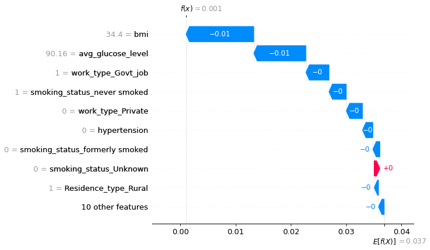

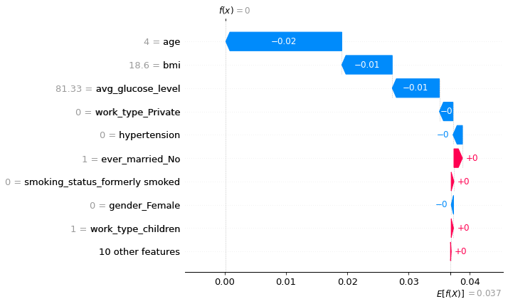

[interactive chart not shown]

Results differ depending on library. In case of `shap` the values have smaller attribution values. For the `person 8` different variable is the most important - in case of `dalex` it's the age and for `shap` bmi. They also have different bias - 0.037 in `shap` and over 0.06 in `dalex`.

## Part 7

[interactive chart not shown]

For XGBoost the most important attributes were age and bmi, where with Linear Regression it's age and governmental job. The very important difference is the bias of - it's around 0.3 where it used to be around 0.06 for XGBoost. We see that the prediction is different, since the model is different, so it's not a surprise that age has much higher attribution value.

# Task B

Discounted value - divided by number of all permutations

|  | Permutation | A's Contribution | Value | Discounted Value |
| --- | --- | --- | --- | --- |
|  | 123 | v(A) | 20 | 20/6 |
|  | 132 | v(A) | 20 | 20/6 |
|  | 213 | v(A,B) - v(B) | 40 | 40/6 |
|  | 231 | v(A,B,C) - v(B,C) | 30 | 30/6 |
|  | 312 | v(A,C) - v(C) | 10 | 10/6 |
|  | 321 | v(A,B,C) - v(B,C) | 30 | 30/6 |
| **Total** |  |  | 150 | 25 |

Hence the Shapley value is 25. Since payout for B is just the same his value is also 25 and from additivity C's Shapley value is 50.